# Project_SocialMedia

Akshita

2024-04-27

Dataset Name: Student Social Media Usage and Weekly Feelings

Description:

This dataset captures the social media usage habits of students along with their weekly feelings, mood, productivity, tiredness, learnings from social media, and interview/career-related interactions. Variables:

Social Media Usage:

Instagram_Time: Time spent on Instagram (in hours per day)

Linkedin_Time: Time spent on LinkedIn (in hours per day)

Snapchat_Time: Time spent on Snapchat (in hours per day)

Twitter_Time: Time spent on Twitter (in hours per day)

Whatsapp_Time: Time spent on WhatsApp (in hours per day)

Youtube_Time: Time spent on YouTube (in hours per day)

OTT_Time: Time spent on Over-the-Top (OTT) platforms (in hours per day)

Reddit_Time: Time spent on Reddit (in hours per day)

Weekly_Feelings: Overall weekly feelings of students on a scale of 1 to 5.

Other Metrics:

Learnings: Amount of learning derived from social media usage (on a scale of 1 to 10)

Data Collection: The dataset was collected through surveys where students reported their daily social media usage and weekly feelings, mood, productivity, and tiredness. Additionally, students reported any interactions or learnings related to their career pursuits.

Use Case: The dataset can be used to analyze the relationship between social media usage patterns and students’ well-being, mood, productivity, and career-related outcomes. It can also be used to explore the impact of different social media platforms on various aspects of students’ lives.

Data Cleaning & Pre=Processing

```r
social_media <- read.csv("C:/Users/HP/Downloads/Social_media_original.csv")
str(social_media)
```

```
## 'data.frame':    21 obs. of  25 variables:
##  $ Enter.5.character.id...not.your.net.id..or.your.name...It.should.be.same.throughout.the.survey.: chr  "masinl" "peace" "Patty" "Bunny" ...
##  $ Instagram                                                                                      : chr  "Yes" "Yes" "Yes" "Yes" ...
##  $ Hours.spent..HH.MM..Input.N.A.if.not.a.user                                                    : chr  "3.5" "7:44" "3:46" "5:23" ...
##  $ Linkedin                                                                                       : chr  "Yes" "Yes" "Yes" "Yes" ...
##  $ Hours.spent..HH.MM..Input.N.A.if.not.a.user.1                                                  : chr  "4" "5:12" "7:00" "5:19" ...
##  $ Snapchat                                                                                       : chr  "Yes" "Yes" "Yes" "Yes" ...
##  $ Hours.spent..HH.MM..Input.N.A.if.not.a.user.2                                                  : chr  "1" "3:41" "0:32" "1:18" ...
##  $ Twitter                                                                                        : chr  "Yes" "No" "No" "No" ...
##  $ Hours.spent..HH.MM..Input.N.A.if.not.a.user.3                                                  : chr  "5" "0:00" "N/A" "N/A" ...
##  $ Whatsapp..Wechat                                                                               : chr  "Yes" "Yes" "Yes" "Yes" ...
##  $ Hours.spent..HH.MM..Input.N.A.if.not.a.user.4                                                  : chr  "1" "4:11" "9:50" "5:18" ...
##  $ Youtube                                                                                        : chr  "Yes" "Yes" "Yes" "Yes" ...
##  $ Hours.spent..HH.MM..Input.N.A.if.not.a.user.5                                                  : chr  "2.5" "4:15" "1:51" "2:00" ...
##  $ OTT..Netflix..Hulu..Prime.video..                                                              : chr  "Yes" "No" "Yes" "Yes" ...
##  $ Hours.spent..HH.MM..Input.N.A.if.not.a.user.6                                                  : chr  "14.5" "0:00" "2:00" "2:00" ...
##  $ Reddit                                                                                         : chr  "Yes" "No" "No" "No" ...
##  $ Hours.spent..HH.MM..Input.N.A.if.not.a.user.7                                                  : chr  "2.5" "0:00" "N/A" "N.A" ...
##  $ Application.type.Social.media..OTT..Learning.                                                  : chr  "OTT" "Social Media" "Social Media" "Social Media" ...
##  $ How.many.job.interview.calls.received.in.this.week..                                           : chr  "N/A" "0" "0" "2" ...
##  $ How.much.networking.done.with.coffee.chats.                                                    : chr  "N/A" "1" "0" "0" ...
##  $ How.many.learning.done.in.terms.of.items.created.                                              : num  3 3 4 4 4 4 3 2 6 2 ...
##  $ Mood.Productivity                                                                              : chr  "Yes" "Yes" "Yes" "Yes" ...
##  $ Tired.waking.up.in.morning                                                                     : chr  "No" "No" "No" "No" ...
##  $ Trouble.falling.asleep                                                                         : chr  "No" "Yes" "No" "No" ...
##  $ How.you.felt.the.entire.week.                                                                  : int  3 3 4 4 3 5 4 4 3 2 ...
```

```r
social_media_cleaned <- social_media[,-1]

#changing column names
change_cols_index <- c(2,4,6,8,10,12,14,16,17,18,19,20,21,22,23,24)
change_cols_name <- c("Instagram_Time", "Linkedin_Time", "Snapchat_Time", "Twitter_Time", "Whatsapp_Time", "Youtube_Time", "OTT_Time", "Reddit_Time", "Application Type", "Interview_call_received", "Networking", "Learning", "Mood_Productivity", "Morning_tireness", "Sleep_trouble", "Weekly_Feelings")
colnames(social_media_cleaned)[change_cols_index] <- change_cols_name


# Convert "NA", "N/A", "n/a", "na", "N.A", "n.a" to 0
social_media_cleaned[social_media_cleaned == "NA" | social_media_cleaned == "N/A" | social_media_cleaned == "na" | social_media_cleaned == "n/a" | social_media_cleaned == "N.A" | social_media_cleaned == "n.a" | social_media_cleaned == "0" | social_media_cleaned == ""] <- NA
social_media_cleaned[is.na(social_media_cleaned)] <- 0

# Define a function to convert time strings to decimal hours
convert_to_decimal_hours <- function(time_string) {
# Check if NA values are present
if (any(is.na(time_string))) {
         return(rep(NA, length(time_string)))  # Return NA for NA values
     }

# Define a function to convert HH:MM format to decimal hours
     hhmm_to_decimal <- function(hhmm) {
         parts <- as.numeric(strsplit(hhmm, ":")[[1]])  # Split into hours and minutes
         hours <- parts[1]
         minutes <- ifelse(length(parts) > 1, parts[2], 0)  # Handle missing minutes
         total_hours <- hours + minutes / 60
         return(total_hours)
     }

# Convert time strings to decimal hours
decimal_hours <- sapply(time_string, function(x) {
         if (grepl("^\\d+:\\d+$", x)) {
             return(hhmm_to_decimal(x))  # Convert HH:MM format
         } else if (grepl("^\\d+\\.\\d+$", x)) {
             return(as.numeric(x))  # Convert decimal format
         } else if (grepl("^\\d+$", x)) {
             return(as.numeric(x))  # Convert whole numbers
         } else {
             return(NA)  # Return NA for other cases
         }
     })

     return(decimal_hours)
}

time_columns <- c("Instagram_Time", "Linkedin_Time", "Snapchat_Time", "Twitter_Time", "Whatsapp_Time", "Youtube_Time", "OTT_Time", "Reddit_Time")
# Apply the conversion function to all time columns
social_media_cleaned[time_columns] <- lapply(social_media_cleaned[time_columns], convert_to_decimal_hours)

#Treating NA in whatsapp column
mean_value <- mean(social_media_cleaned$Whatsapp_Time, na.rm = TRUE)
social_media_cleaned$Whatsapp_Time[is.na(social_media_cleaned$Whatsapp_Time)] <- mean_value

# Verify the result
str(social_media_cleaned)
```

```
## 'data.frame':    21 obs. of  24 variables:
##  $ Instagram                        : chr  "Yes" "Yes" "Yes" "Yes" ...
##  $ Instagram_Time                   : num  3.5 7.73 3.77 5.38 0 ...
##  $ Linkedin                         : chr  "Yes" "Yes" "Yes" "Yes" ...
##  $ Linkedin_Time                    : num  4 5.2 7 5.317 0.583 ...
##  $ Snapchat                         : chr  "Yes" "Yes" "Yes" "Yes" ...
##  $ Snapchat_Time                    : num  1 3.683 0.533 1.3 0 ...
##  $ Twitter                          : chr  "Yes" "No" "No" "No" ...
##  $ Twitter_Time                     : num  5 0 0 0 0.667 ...
##  $ Whatsapp..Wechat                 : chr  "Yes" "Yes" "Yes" "Yes" ...
##  $ Whatsapp_Time                    : num  1 4.18 9.83 5.3 3 ...
##  $ Youtube                          : chr  "Yes" "Yes" "Yes" "Yes" ...
##  $ Youtube_Time                     : num  2.5 4.25 1.85 2 3.5 7 3 2 4 3 ...
##  $ OTT..Netflix..Hulu..Prime.video..: chr  "Yes" "No" "Yes" "Yes" ...
##  $ OTT_Time                         : num  14.5 0 2 2 2 3 0 3 3 0 ...
##  $ Reddit                           : chr  "Yes" "No" "No" "No" ...
##  $ Reddit_Time                      : num  2.5 0 0 0 1 0 0 0 0 0 ...
##  $ Application Type                 : chr  "OTT" "Social Media" "Social Media" "Social Media" ...
##  $ Interview_call_received          : chr  "0" "0" "0" "2" ...
##  $ Networking                       : chr  "0" "1" "0" "0" ...
##  $ Learning                         : num  3 3 4 4 4 4 3 2 6 2 ...
##  $ Mood_Productivity                : chr  "Yes" "Yes" "Yes" "Yes" ...
##  $ Morning_tireness                 : chr  "No" "No" "No" "No" ...
##  $ Sleep_trouble                    : chr  "No" "Yes" "No" "No" ...
##  $ Weekly_Feelings                  : int  3 3 4 4 3 5 4 4 3 2 ...
```

```r
# Convert 'No' and 'Yes' to 0 and 1
social_media_cleaned$Mood_Productivity <- ifelse(social_media_cleaned$Mood_Productivity == "No", 0, 1)

social_media_cleaned$Morning_tireness <- ifelse(social_media_cleaned$Morning_tireness == "No", 0, 1)

social_media_cleaned$Sleep_trouble <- ifelse(social_media_cleaned$Sleep_trouble == "No", 0, 1)

# Select the relevant columns
time_columns <- social_media_cleaned[, grepl("_Time", colnames(social_media_cleaned))]
other_columns <- social_media_cleaned[c("Weekly_Feelings")]

# Combine the columns
combined_data <- cbind(time_columns, other_columns)

# Check the structure of the dataset
str(combined_data)
```

```
## 'data.frame':    21 obs. of  9 variables:
##  $ Instagram_Time : num  3.5 7.73 3.77 5.38 0 ...
##  $ Linkedin_Time  : num  4 5.2 7 5.317 0.583 ...
##  $ Snapchat_Time  : num  1 3.683 0.533 1.3 0 ...
##  $ Twitter_Time   : num  5 0 0 0 0.667 ...
##  $ Whatsapp_Time  : num  1 4.18 9.83 5.3 3 ...
##  $ Youtube_Time   : num  2.5 4.25 1.85 2 3.5 7 3 2 4 3 ...
##  $ OTT_Time       : num  14.5 0 2 2 2 3 0 3 3 0 ...
##  $ Reddit_Time    : num  2.5 0 0 0 1 0 0 0 0 0 ...
##  $ Weekly_Feelings: int  3 3 4 4 3 5 4 4 3 2 ...
```

```r
summary(combined_data)
```

```
##  Instagram_Time   Linkedin_Time    Snapchat_Time     Twitter_Time
##  Min.   : 0.000   Min.   : 0.000   Min.   :0.0000   Min.   :0.0000
##  1st Qu.: 3.500   1st Qu.: 1.917   1st Qu.:0.0000   1st Qu.:0.0000
##  Median : 5.367   Median : 3.917   Median :0.5333   Median :0.0000
##  Mean   : 5.352   Mean   : 3.624   Mean   :1.2954   Mean   :0.5802
##  3rd Qu.: 7.000   3rd Qu.: 5.000   3rd Qu.:1.4167   3rd Qu.:0.2667
##  Max.   :15.017   Max.   :10.000   Max.   :7.3167   Max.   :5.0000
##  Whatsapp_Time     Youtube_Time      OTT_Time       Reddit_Time
##  Min.   : 1.000   Min.   :0.000   Min.   : 0.000   Min.   :0.0000
##  1st Qu.: 3.667   1st Qu.:2.000   1st Qu.: 0.000   1st Qu.:0.0000
##  Median : 6.000   Median :3.000   Median : 1.683   Median :0.0000
##  Mean   : 6.332   Mean   :2.973   Mean   : 2.361   Mean   :0.5245
##  3rd Qu.: 8.917   3rd Qu.:4.000   3rd Qu.: 2.467   3rd Qu.:0.0000
##  Max.   :15.350   Max.   :7.000   Max.   :14.500   Max.   :7.0000
##  Weekly_Feelings
##  Min.   :2.000
##  1st Qu.:3.000
##  Median :3.000
##  Mean   :3.429
##  3rd Qu.:4.000
##  Max.   :5.000
```

Visualizing

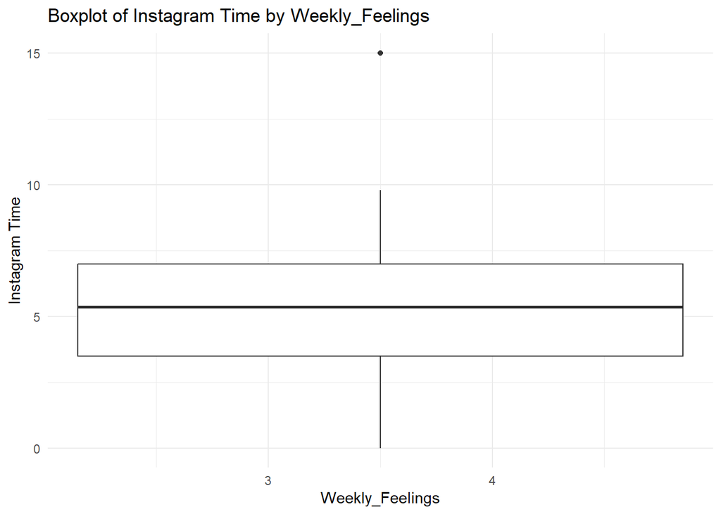

```r
library(ggplot2)
# Create a boxplot for Instagram_Time by Feelings_Category
ggplot(data = combined_data, aes(x = Weekly_Feelings, y = Instagram_Time, fill = Weekly_Feelings)) +
     geom_boxplot() +
     labs(title = "Boxplot of Instagram Time by Weekly_Feelings",
          x = "Weekly_Feelings",
          y = "Instagram Time") +
     theme_minimal()
```

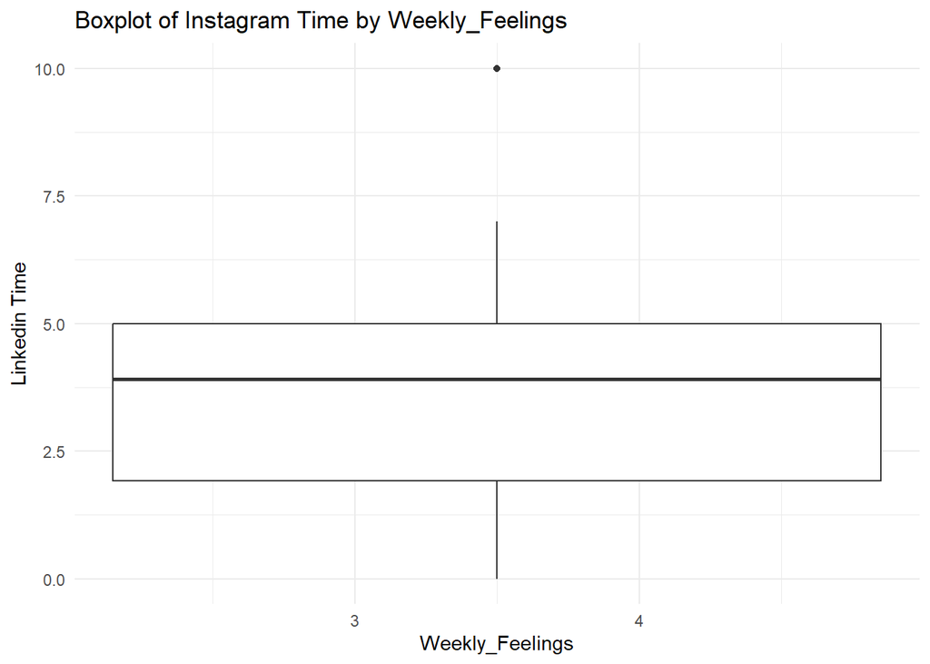

```r
ggplot(data = combined_data, aes(x = Weekly_Feelings, y = Linkedin_Time, fill = Weekly_Feelings)) +
     geom_boxplot() +
     labs(title = "Boxplot of Instagram Time by Weekly_Feelings",
          x = "Weekly_Feelings",
          y = "Linkedin Time") +
     theme_minimal()
```

[figure not shown]

```r
ggplot(data = combined_data, aes(x = Weekly_Feelings, y = Snapchat_Time, fill = Weekly_Feelings)) +
     geom_boxplot() +
     labs(title = "Boxplot of Instagram Time by Weekly_Feelings",
          x = "Weekly_Feelings",
          y = "Snapchat Time") +
     theme_minimal()
```

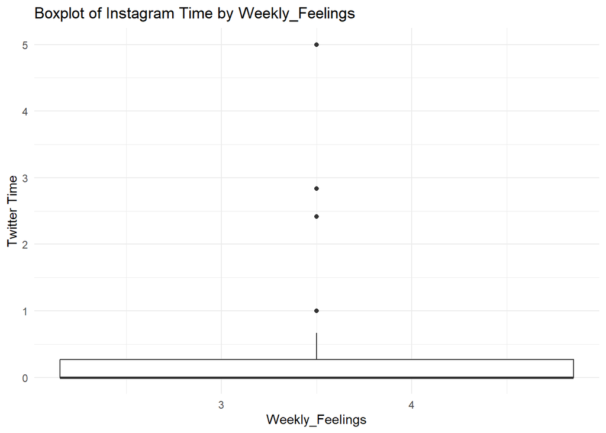

```r
ggplot(data = combined_data, aes(x = Weekly_Feelings, y = Twitter_Time, fill = Weekly_Feelings)) +
     geom_boxplot() +
     labs(title = "Boxplot of Instagram Time by Weekly_Feelings",
          x = "Weekly_Feelings",
          y = "Twitter Time") +
     theme_minimal()
```

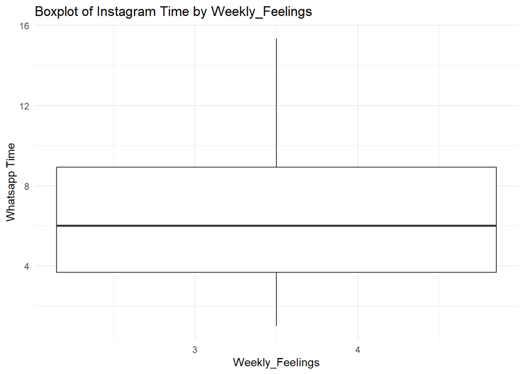

```r
ggplot(data = combined_data, aes(x = Weekly_Feelings, y = Whatsapp_Time, fill = Weekly_Feelings)) +
     geom_boxplot() +
     labs(title = "Boxplot of Instagram Time by Weekly_Feelings",
          x = "Weekly_Feelings",
          y = "Whatsapp Time") +
     theme_minimal()
```

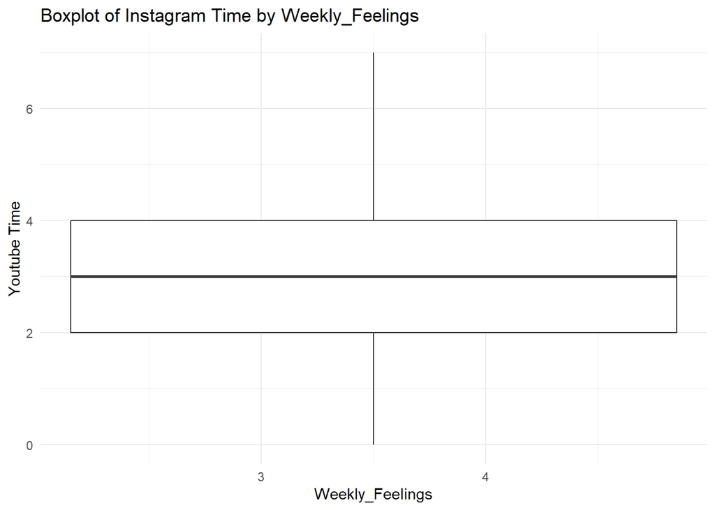

```r
ggplot(data = combined_data, aes(x = Weekly_Feelings, y = Youtube_Time, fill = Weekly_Feelings)) +
     geom_boxplot() +
     labs(title = "Boxplot of Instagram Time by Weekly_Feelings",
          x = "Weekly_Feelings",
          y = "Youtube Time") +
     theme_minimal()
```

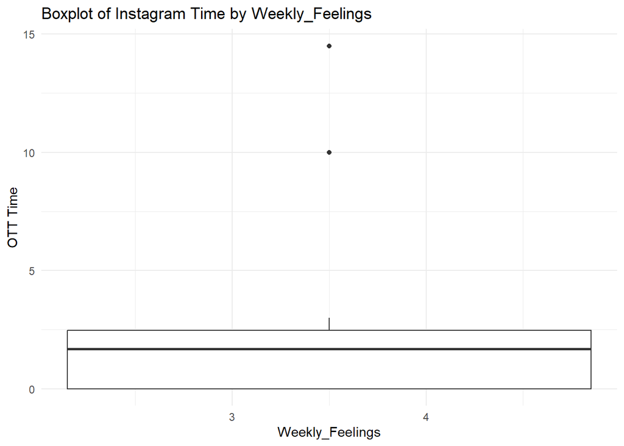

```r
ggplot(data = combined_data, aes(x = Weekly_Feelings, y = OTT_Time, fill = Weekly_Feelings)) +
     geom_boxplot() +
     labs(title = "Boxplot of Instagram Time by Weekly_Feelings",
          x = "Weekly_Feelings",
          y = "OTT Time") +
     theme_minimal()
```

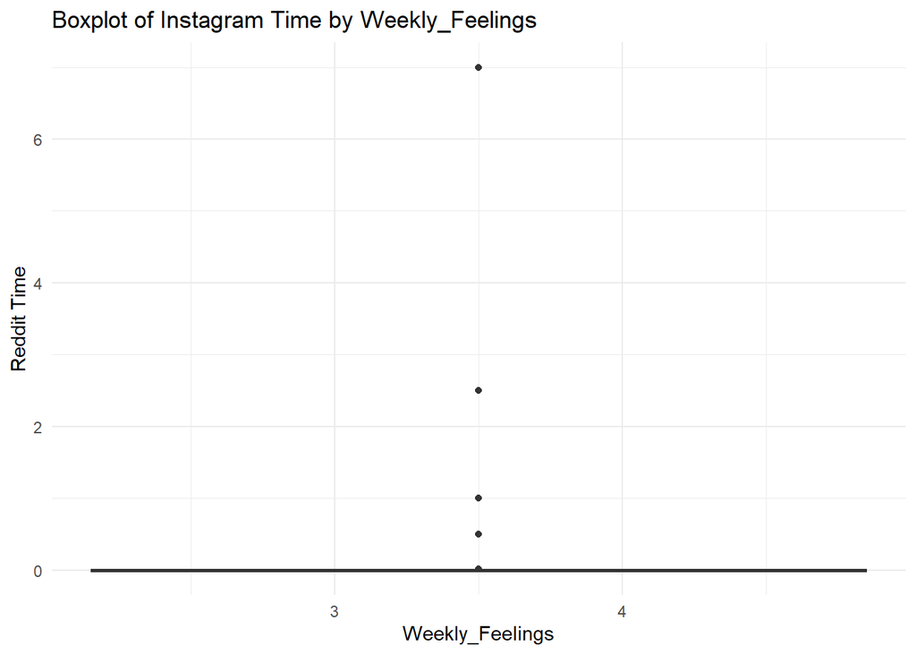

```r
ggplot(data = combined_data, aes(x = Weekly_Feelings, y = Reddit_Time, fill = Weekly_Feelings)) +
     geom_boxplot() +
     labs(title = "Boxplot of Instagram Time by Weekly_Feelings",
          x = "Weekly_Feelings",
          y = "Reddit Time") +
     theme_minimal()
```

```r
# Exclude the 'Weekly_Feelings' column before calculating the correlation matrix
numeric_data <- combined_data[, -which(names(combined_data) == "Weekly_Feelings")]

# Calculate the correlation matrix
correlation_matrix <- cor(numeric_data)
print(correlation_matrix)
```

```
##                Instagram_Time Linkedin_Time Snapchat_Time Twitter_Time
## Instagram_Time      1.0000000   0.312136719    0.75664722   -0.2081875
## Linkedin_Time       0.3121367   1.000000000    0.38172781   -0.1300779
## Snapchat_Time       0.7566472   0.381727806    1.00000000   -0.1669074
## Twitter_Time       -0.2081875  -0.130077891   -0.16690740    1.0000000
## Whatsapp_Time       0.5729352   0.262416318    0.40952048   -0.4874131
## Youtube_Time        0.2832555   0.452170173    0.24346648   -0.1882119
## OTT_Time            0.2899576   0.185481917    0.45625980    0.5570731
## Reddit_Time        -0.1278472  -0.007102435   -0.02822626    0.1648546
##                Whatsapp_Time Youtube_Time  OTT_Time  Reddit_Time
## Instagram_Time     0.5729352    0.2832555 0.2899576 -0.127847241
## Linkedin_Time      0.2624163    0.4521702 0.1854819 -0.007102435
## Snapchat_Time      0.4095205    0.2434665 0.4562598 -0.028226256
## Twitter_Time      -0.4874131   -0.1882119 0.5570731  0.164854559
## Whatsapp_Time      1.0000000    0.4178303 0.1515804 -0.126931653
## Youtube_Time       0.4178303    1.0000000 0.1605431  0.026216397
## OTT_Time           0.1515804    0.1605431 1.0000000  0.232735069
## Reddit_Time       -0.1269317    0.0262164 0.2327351  1.000000000
```

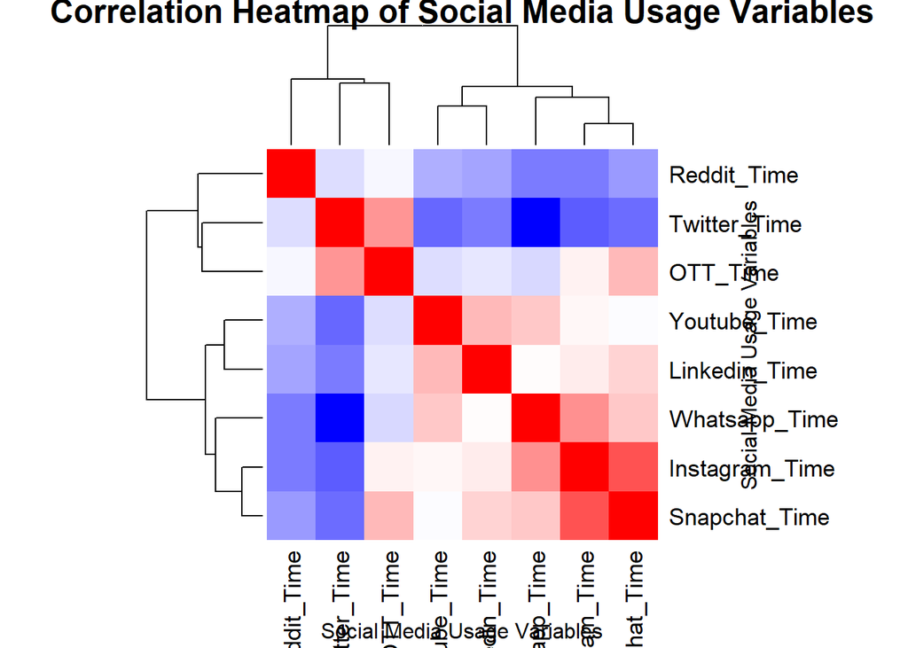

```r
# Create a heatmap for the correlation matrix
heatmap(correlation_matrix,
        symm = TRUE,        # Display symmetrically
        main = "Correlation Heatmap of Social Media Usage Variables",
        xlab = "Social Media Usage Variables",
        ylab = "Social Media Usage Variables",
        col = colorRampPalette(c("blue", "white", "red"))(100), # Choose a color palette
        scale = "none")     # Add a color scale
```

[figure not shown]

```r
# Scale the variables
scaled_data <- scale(combined_data[, -c(9)])  # Exclude the first and last columns (ID and Feelings_Category)

#comparing original and scaled values
# Plot histograms for original data
par(mfrow=c(2, ncol(combined_data) - 1))  # Set up plotting layout

for (i in 1:(ncol(combined_data) - 1)) {  # Exclude the last column (Feelings_Category)
  hist(combined_data[, i], main = paste("Original", names(combined_data)[i]), xlab = names(combined_data)[i], col = "lightblue")
}

# Plot histograms for scaled data
for (i in 1:(ncol(scaled_data))) {
  hist(scaled_data[, i], main = paste("Scaled", names(scaled_data)[i]), xlab = names(scaled_data)[i], col = "lightgreen")
}
```

EDA

```r
# Install and load the psych package
library(psych)
# Perform PCA
pca_result <- prcomp(scaled_data)
print(pca_result)
```

```
## Standard deviations (1, .., p=8):
## [1] 1.7079972 1.3292680 1.0248597 0.9206865 0.8055752 0.6367415 0.5224185
## [8] 0.3007964
##
## Rotation (n x k) = (8 x 8):
##                        PC1         PC2         PC3         PC4         PC5
## Instagram_Time  0.48791971 -0.03238984  0.34573404  0.13341856 -0.08355268
## Linkedin_Time   0.35238567 -0.05358586 -0.42509710 -0.44055377 -0.56820720
## Snapchat_Time   0.47291980 -0.16782666  0.29648016  0.12976707 -0.34071338
## Twitter_Time   -0.20714024 -0.62591082  0.10163426 -0.31991949  0.16432474
## Whatsapp_Time   0.44497690  0.21189009  0.02145661  0.22423165  0.48165803
## Youtube_Time    0.35001922  0.02655931 -0.57097538 -0.24925619  0.44702878
## OTT_Time        0.21782823 -0.63856523  0.10583379 -0.03518371  0.25455695
## Reddit_Time    -0.05684581 -0.35040114 -0.51366951  0.74516945 -0.17447885
##                        PC6         PC7         PC8
## Instagram_Time -0.26480168  0.66470237 -0.32345402
## Linkedin_Time   0.39839713  0.12775669 -0.01600799
## Snapchat_Time  -0.29759290 -0.46962987  0.46716351
## Twitter_Time   -0.01867673  0.39764376  0.51689319
## Whatsapp_Time   0.57687457  0.09504367  0.36406854
## Youtube_Time   -0.53404162 -0.05839652  0.01393817
## OTT_Time        0.25314424 -0.36060570 -0.52290430
## Reddit_Time    -0.01351724  0.14386205  0.05942934
```

```r
summary(pca_result)
```

```
## Importance of components:
##                           PC1    PC2    PC3    PC4     PC5     PC6     PC7
## Standard deviation     1.7080 1.3293 1.0249 0.9207 0.80558 0.63674 0.52242
## Proportion of Variance 0.3647 0.2209 0.1313 0.1060 0.08112 0.05068 0.03412
## Cumulative Proportion  0.3647 0.5855 0.7168 0.8228 0.90390 0.95458 0.98869
##                            PC8
## Standard deviation     0.30080
## Proportion of Variance 0.01131
## Cumulative Proportion  1.00000
```

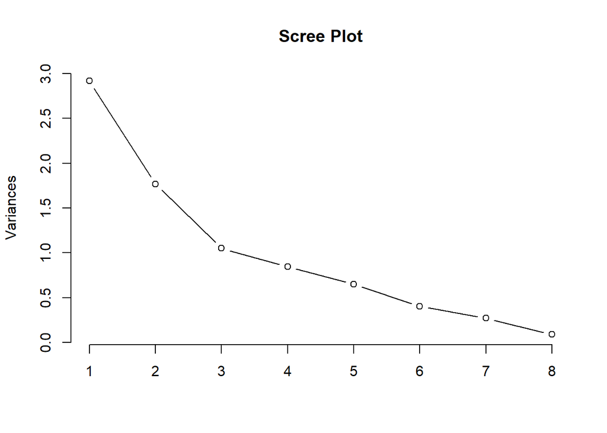

```r
# Scree plot
plot(pca_result, type = "l", main = "Scree Plot")
```

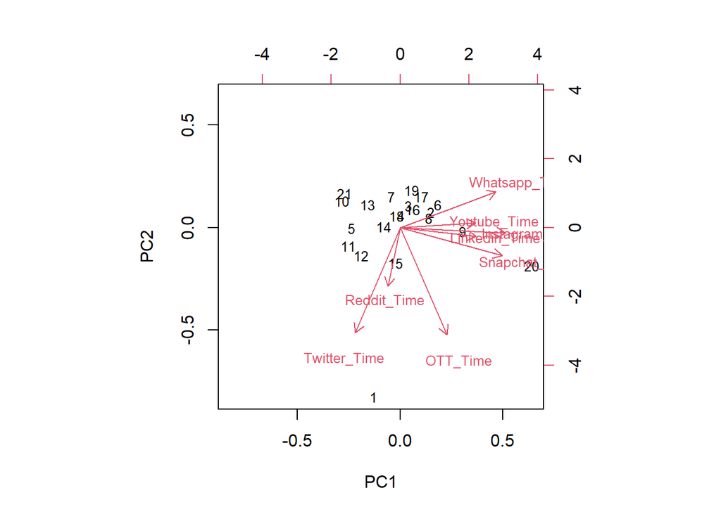

```r
# Biplot
biplot(pca_result, cex = 0.8)
```

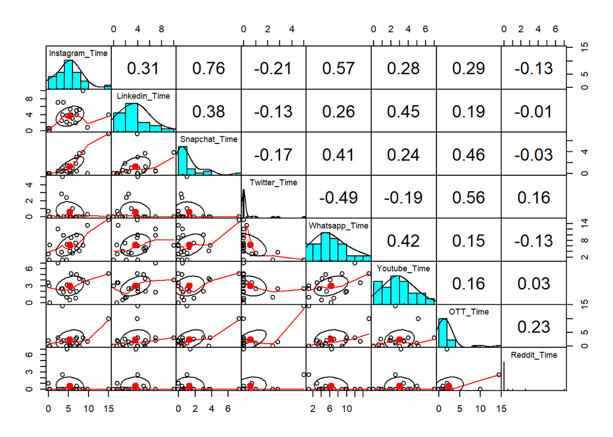

```r
# Correlation
pairs.panels(combined_data[, -ncol(combined_data)],
              gap = 0,
              bg = c("red", "blue")[combined_data$Feelings_Category],
              pch=21)
```

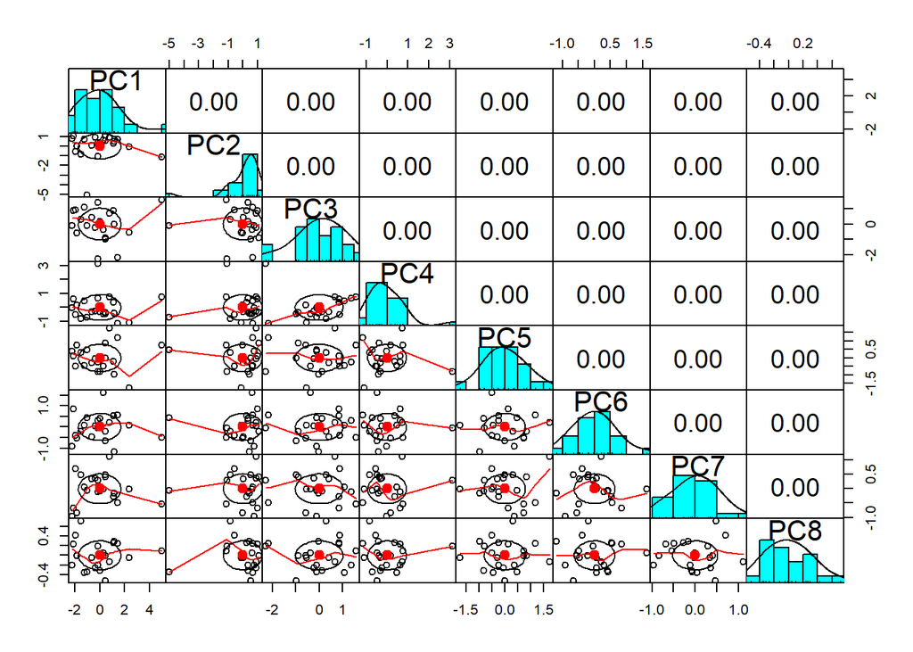

```r
pairs.panels(pca_result$x,
              gap=0,
              bg = c("red", "blue")[combined_data$Feelings_Category],
              pch=21)
```

Variance explained by each Principal Component (PC):

PC1 explains the highest proportion of variance at 36.47%, followed by PC2 with 22.09%.

The cumulative proportion of variance explained by PC1 and PC2 is 58.55%, indicating that these two components capture a significant amount of the overall variability in the data.

Subsequent components contribute progressively less to the total variance.

Interpretation of Principal Components:

PC1: It seems to be heavily influenced by variables like Instagram_Time, Linkedin_Time, Snapchat_Time, and Whatsapp_Time, as they have relatively high loadings on this component. This suggests that PC1 captures the overall usage pattern across these social media platforms.

PC2: Variables like Twitter_Time, OTT_Time, and Reddit_Time have higher loadings on this component. PC2 might represent a different aspect of social media usage or engagement compared to PC1.

Loadings of Variables on Principal Components:

Loadings represent the correlation between each variable and the principal component. Higher absolute values of loadings indicate stronger associations.

For example, Instagram_Time has a high positive loading on PC1, indicating that higher Instagram usage contributes significantly to this component.

Interpretation of PC Rotation:

Rotation provides insight into the relationship between original variables and principal components.

For instance, the negative loading of Reddit_Time on PC1 suggests an inverse relationship between Reddit usage and the overall social media usage pattern captured by PC1.

```r
# Perform Factor Analysis
fa_result <- fa(scaled_data, nfactors = 3, rotate = "varimax")
print(fa_result)
```

```
## Factor Analysis using method =  minres
## Call: fa(r = scaled_data, nfactors = 3, rotate = "varimax")
## Standardized loadings (pattern matrix) based upon correlation matrix
##                  MR1   MR2   MR3    h2     u2 com
## Instagram_Time  0.85 -0.12  0.17 0.757 0.2432 1.1
## Linkedin_Time   0.31  0.01  0.40 0.263 0.7374 1.9
## Snapchat_Time   0.85  0.04  0.15 0.739 0.2613 1.1
## Twitter_Time   -0.16  0.86 -0.21 0.801 0.1992 1.2
## Whatsapp_Time   0.53 -0.31  0.36 0.503 0.4973 2.4
## Youtube_Time    0.12  0.02  0.99 0.996 0.0042 1.0
## OTT_Time        0.48  0.76  0.11 0.817 0.1826 1.7
## Reddit_Time    -0.07  0.27  0.04 0.077 0.9228 1.2
##
##                        MR1  MR2  MR3
## SS loadings           2.09 1.49 1.38
## Proportion Var        0.26 0.19 0.17
## Cumulative Var        0.26 0.45 0.62
## Proportion Explained  0.42 0.30 0.28
## Cumulative Proportion 0.42 0.72 1.00
##
## Mean item complexity =  1.5
## Test of the hypothesis that 3 factors are sufficient.
##
## df null model =  28  with the objective function =  3.51 with Chi Square =  57.96
## df of  the model are 7  and the objective function was  0.59
##
## The root mean square of the residuals (RMSR) is  0.04
## The df corrected root mean square of the residuals is  0.08
##
## The harmonic n.obs is  21 with the empirical chi square  1.9  with prob <  0.96
## The total n.obs was  21  with Likelihood Chi Square =  8.56  with prob <  0.29
##
## Tucker Lewis Index of factoring reliability =  0.728
## RMSEA index =  0.091  and the 90 % confidence intervals are  0 0.308
## BIC =  -12.75
## Fit based upon off diagonal values = 0.99
## Measures of factor score adequacy
##                                                    MR1  MR2 MR3
## Correlation of (regression) scores with factors   0.94 0.94   1
## Multiple R square of scores with factors          0.88 0.88   1
## Minimum correlation of possible factor scores     0.77 0.75   1
```

```r
# Summary of Factor Analysis
summary(fa_result)
```

```
##
## Factor analysis with Call: fa(r = scaled_data, nfactors = 3, rotate = "varimax")
##
## Test of the hypothesis that 3 factors are sufficient.
## The degrees of freedom for the model is 7  and the objective function was  0.59
## The number of observations was  21  with Chi Square =  8.56  with prob <  0.29
##
## The root mean square of the residuals (RMSA) is  0.04
## The df corrected root mean square of the residuals is  0.08
##
## Tucker Lewis Index of factoring reliability =  0.728
## RMSEA index =  0.091  and the 10 % confidence intervals are  0 0.308
## BIC =  -12.75
```

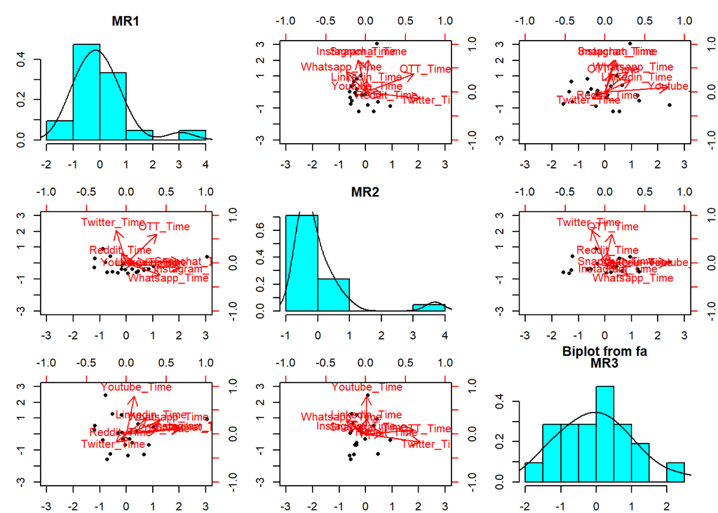

```r
# Biplot of factor loadings
biplot(fa_result)
```

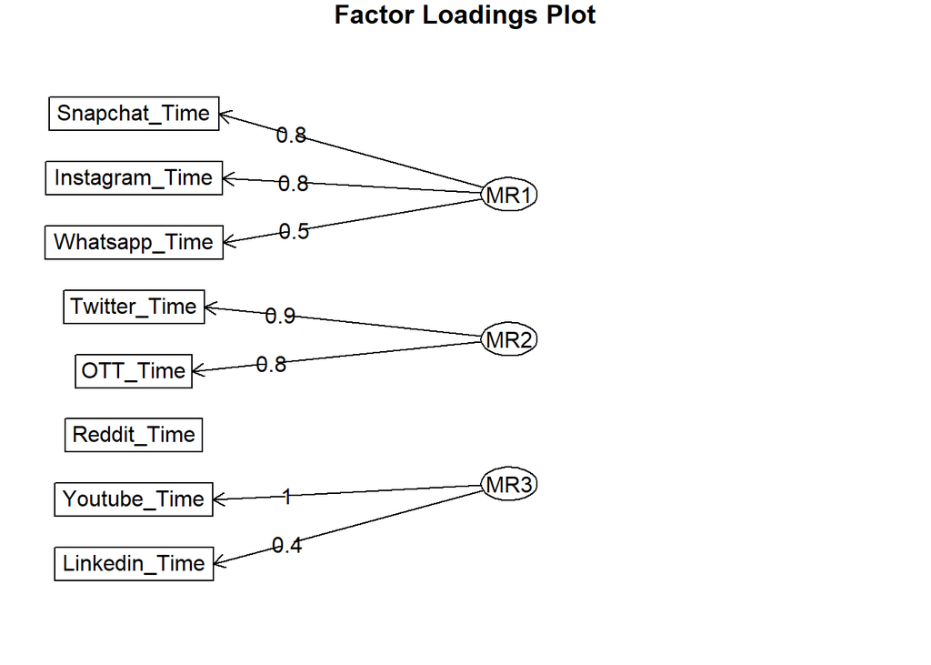

```r
# Factor loadings plot
factor_loading_plot <- fa.diagram(fa_result, main = "Factor Loadings Plot")
```

```r
#1. Kaiser's Criterion:
# Extract eigenvalues from FA results
eigenvalues <- fa_result$values
print(eigenvalues)
```

```
## [1]  2.60783036  1.51063781  0.83435952  0.16593746  0.13328096 -0.02445448
## [7] -0.07918930 -0.19630440
```

```r
# Retain factors with eigenvalues greater than 1
num_factors_kaiser <- sum(eigenvalues > 1)
print(num_factors_kaiser)
```

```
## [1] 2
```

```r
# Factor loadings
fa_loadings <- fa_result$loadings
# Interpret factor loadings
print(fa_loadings)
```

```
##
## Loadings:
##                MR1    MR2    MR3
## Instagram_Time  0.846 -0.117  0.167
## Linkedin_Time   0.315         0.404
## Snapchat_Time   0.846         0.145
## Twitter_Time   -0.163  0.856 -0.206
## Whatsapp_Time   0.530 -0.306  0.358
## Youtube_Time    0.124         0.990
## OTT_Time        0.480  0.759  0.108
## Reddit_Time            0.267
##
##                  MR1   MR2   MR3
## SS loadings    2.088 1.488 1.376
## Proportion Var 0.261 0.186 0.172
## Cumulative Var 0.261 0.447 0.619
```

```r
# Access communalities
communalities <- fa_result$communality
# Interpret communalities
print(communalities)
```

```
## Instagram_Time  Linkedin_Time  Snapchat_Time   Twitter_Time  Whatsapp_Time
##     0.75678552     0.26260355     0.73872508     0.80076257     0.50271955
##   Youtube_Time       OTT_Time    Reddit_Time
##     0.99584721     0.81744187     0.07721258
```

Factor Loadings:

Each variable’s loading on each factor indicates the strength and direction of its relationship with that factor. For example, in Factor 1 (MR1), variables like Instagram_Time, Snapchat_Time, and Whatsapp_Time have high loadings, suggesting they are strongly associated with this factor.

Factor 3 (MR3) has high loadings for Youtube_Time, indicating its strong association with this factor.

Eigenvalues and Kaiser’s Criterion:

Eigenvalues represent the variance explained by each factor. Factors with eigenvalues greater than 1 are typically retained, suggesting they explain more variance than individual variables.

In this case, Kaiser’s Criterion suggests retaining two factors, as they have eigenvalues greater than 1.

Communalities:

Communalities represent the proportion of variance in each variable that is accounted for by the extracted factors.

Higher communalities indicate that a larger portion of the variance in the variable is explained by the factors.

For example, variables like Instagram_Time and Youtube_Time have high communalities, indicating that a significant portion of their variance is explained by the extracted factors.

```r
library(cluster)
# Perform hierarchical clustering
dist_matrix <- dist(scaled_data)
colnames(dist_matrix) <- rownames(dist_matrix)
print(dist_matrix)
```

```
##           1        2        3        4        5        6        7        8
## 2  6.316776
## 3  6.046296 3.011908
## 4  5.643687 2.063951 1.466097
## 5  5.339438 3.721660 3.531552 2.886628
## 6  6.634089 3.625487 3.055007 3.551896 4.134827
## 7  6.047869 2.352452 1.856219 1.215401 2.438169 3.251920
## 8  5.954574 2.220848 2.067760 1.683900 3.644074 3.710449 2.235915
## 9  6.403871 2.195805 3.036611 2.804734 5.160565 3.655079 3.504373 2.926415
## 10 6.186003 3.803428 3.846806 3.034953 1.171463 4.693695 2.537128 3.918674
## 11 4.985237 3.637793 3.586321 2.693675 2.660530 5.291170 2.657847 3.562670
## 12 4.448350 3.498470 3.268865 2.649218 2.270599 4.408688 2.483871 3.351399
## 13 6.025225 3.181513 2.820071 1.864524 2.531070 4.892141 1.840555 2.528131
## 14 5.266992 2.225450 2.546638 1.385552 2.270510 4.006445 1.295900 2.273029
## 15 6.155424 4.801846 4.752407 4.504003 4.396196 5.357439 4.505240 4.672921
## 16 5.963827 1.920430 2.541019 1.907204 2.963446 2.698323 1.416187 2.672891
## 17 6.653139 3.648048 3.342257 3.217043 3.903649 3.909870 2.655904 2.590956
## 18 5.839830 2.782111 2.535307 1.678218 3.047312 4.564089 2.020619 1.476793
## 19 6.424497 2.529712 2.433329 2.294014 2.927874 2.235518 1.439085 2.637493
## 20 7.582449 4.977730 6.060179 5.813438 7.292425 5.911159 6.248056 4.479236
## 21 6.427043 4.306444 3.186482 2.849700 2.396473 5.120651 2.662926 3.363721
##           9       10       11       12       13       14       15       16
## 2
## 3
## 4
## 5
## 6
## 7
## 8
## 9
## 10 5.431935
## 11 4.887070 2.694582
## 12 4.624511 2.724004 1.276276
## 13 4.532077 2.301022 2.069563 2.584930
## 14 3.626012 2.397960 1.669924 1.677138 1.534438
## 15 5.399468 5.108368 5.219808 5.054000 4.800963 4.583814
## 16 2.945271 3.247652 3.437213 3.044316 2.997864 1.940478 4.363642
## 17 4.675609 4.214613 4.155776 3.764612 3.232319 3.028990 5.157398 2.971747
## 18 3.946683 3.105097 2.696788 2.880699 1.244362 1.726839 4.707228 2.922931
## 19 3.587567 3.237431 3.713908 3.140662 3.101127 2.311725 4.693123 1.239642
```

[output cut: 8 more lines]

```
## 7
## 8
## 9
## 10
## 11
## 12
## 13
## 14
## 15
## 16
## 17
## 18 2.671239
## 19 2.319307 2.968701
## 20 5.179434 5.531189 5.842274
## 21 3.873138 2.366837 3.670571 7.624332
```

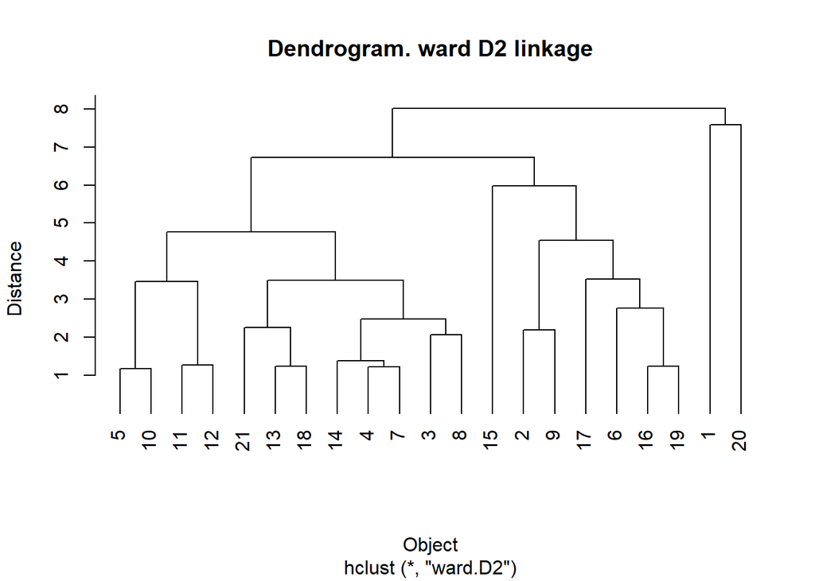

```r
# Clustering
hclust_result <- hclust(dist_matrix, method = "ward.D2")
plot(hclust_result, hang=-1,xlab="Object",ylab="Distance",
     main="Dendrogram. ward D2 linkage")
```

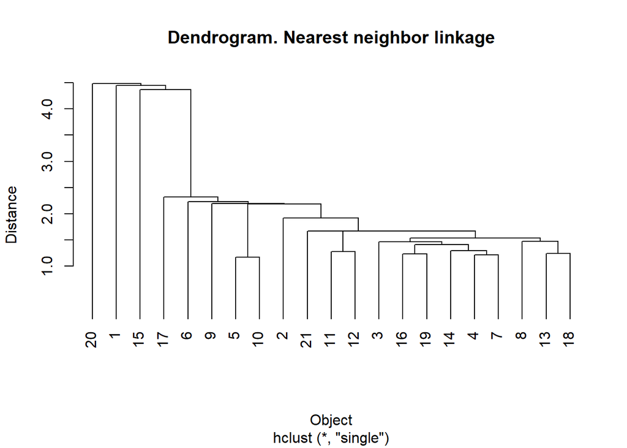

```r
# Invoking hclust command (cluster analysis by single linkage method)
clus_sm.1 <- hclust(dist_matrix, method = "single")
plot(clus_sm.1, hang=-1,xlab="Object",ylab="Distance",
     main="Dendrogram. Nearest neighbor linkage")
```

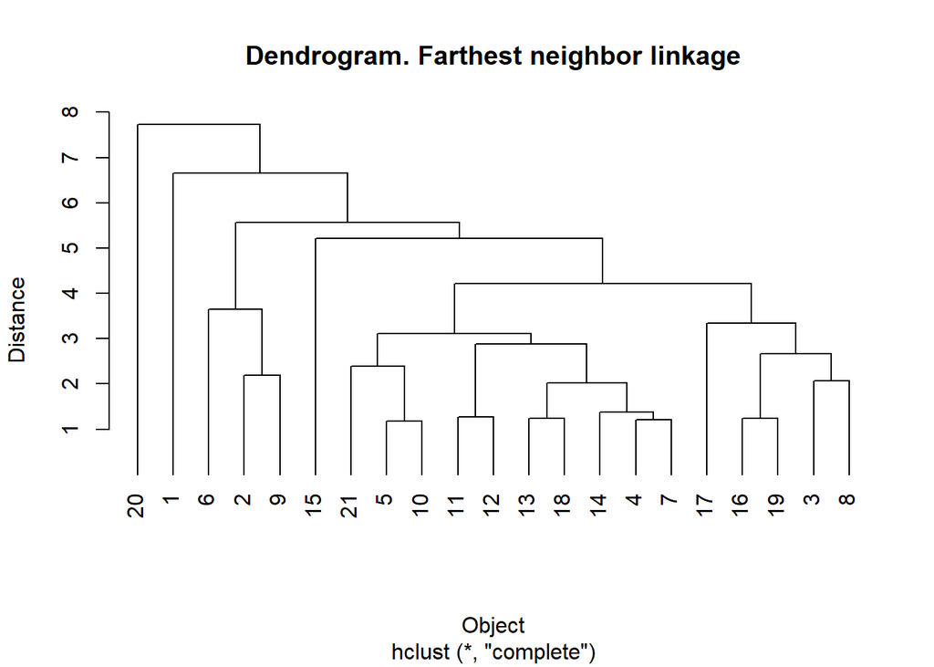

```r
#Default - Complete
clus_sm.2 <- hclust(dist_matrix)
plot(clus_sm.2,hang=-1,xlab="Object",ylab="Distance",
     main="Dendrogram. Farthest neighbor linkage")
```

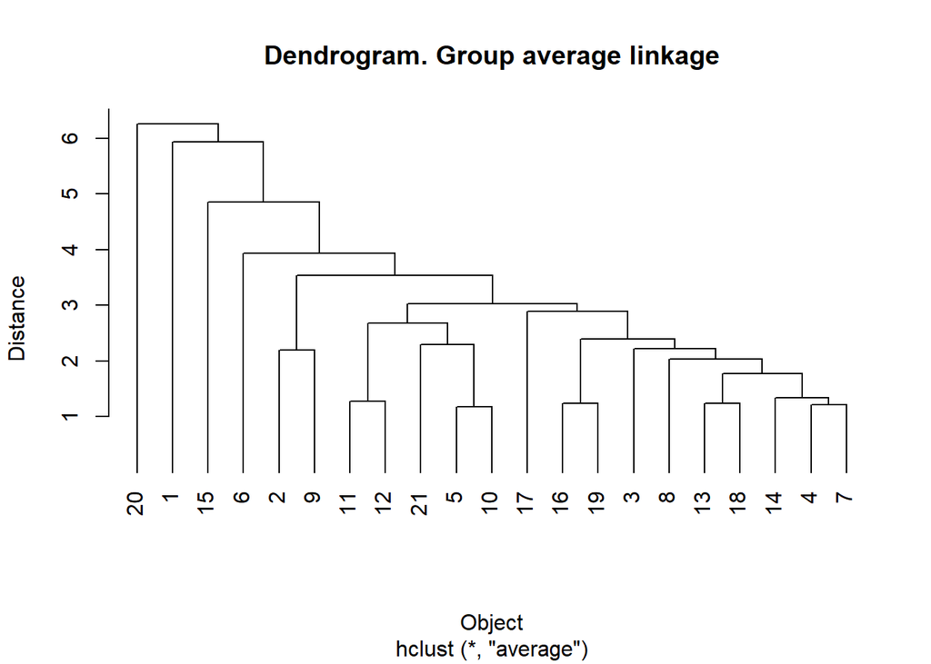

```r
#Average
clus_sm.3 <- hclust(dist_matrix,method="average")
plot(clus_sm.3,hang=-1,xlab="Object",ylab="Distance",
     main="Dendrogram. Group average linkage")
```

```r
# We will use agnes function as it allows us to select option for data standardization, the distance measure and clustering algorithm in one single function
(agn.sm <- agnes(scaled_data, metric="euclidean", stand=TRUE, method = "single"))
```

```
## Call:     agnes(x = scaled_data, metric = "euclidean", stand = TRUE, method = "single")
## Agglomerative coefficient:  0.631338
## Order of objects:
##  [1]  1  2  3  4  7 14 16 19  8 13 18 21 11 12  5 10  9  6 17 20 15
## Height (summary):
##    Min. 1st Qu.  Median    Mean 3rd Qu.    Max.
##   1.720   1.866   2.219   3.001   3.064   7.717
##
## Available components:
## [1] "order"  "height" "ac"     "merge"  "diss"   "call"   "method" "data"
```

```r
#  Description of cluster merging
agn.sm$merge
```

```
##       [,1] [,2]
##  [1,]  -16  -19
##  [2,]  -11  -12
##  [3,]   -4   -7
##  [4,]  -13  -18
##  [5,]    3  -14
##  [6,]    5    1
##  [7,]   -5  -10
##  [8,]   -3    6
##  [9,]   -8    4
## [10,]    8    9
## [11,]   10  -21
## [12,]   11    2
## [13,]   -2   12
## [14,]   13    7
## [15,]   14   -9
## [16,]   15   -6
## [17,]   16  -17
## [18,]   17  -20
## [19,]   -1   18
## [20,]   19  -15
```

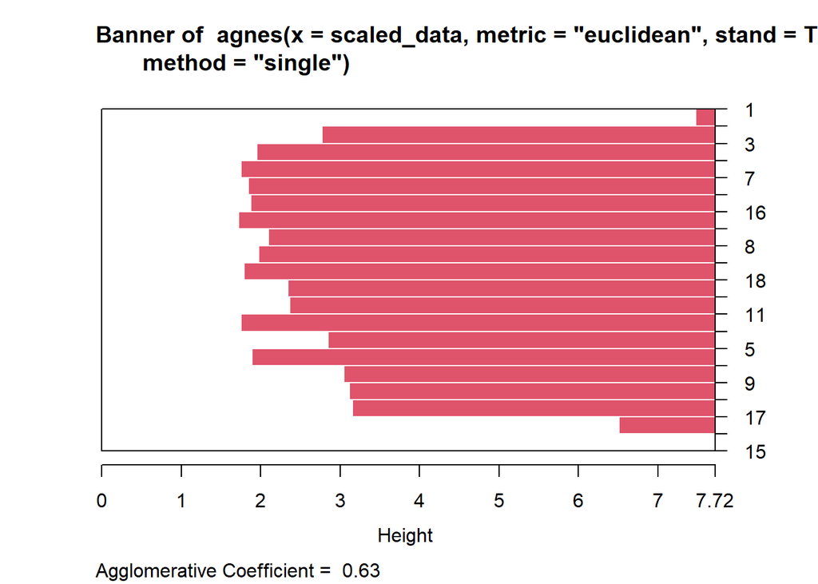

```r
#Interactive Plots
plot(agn.sm, which.plots=1)
```

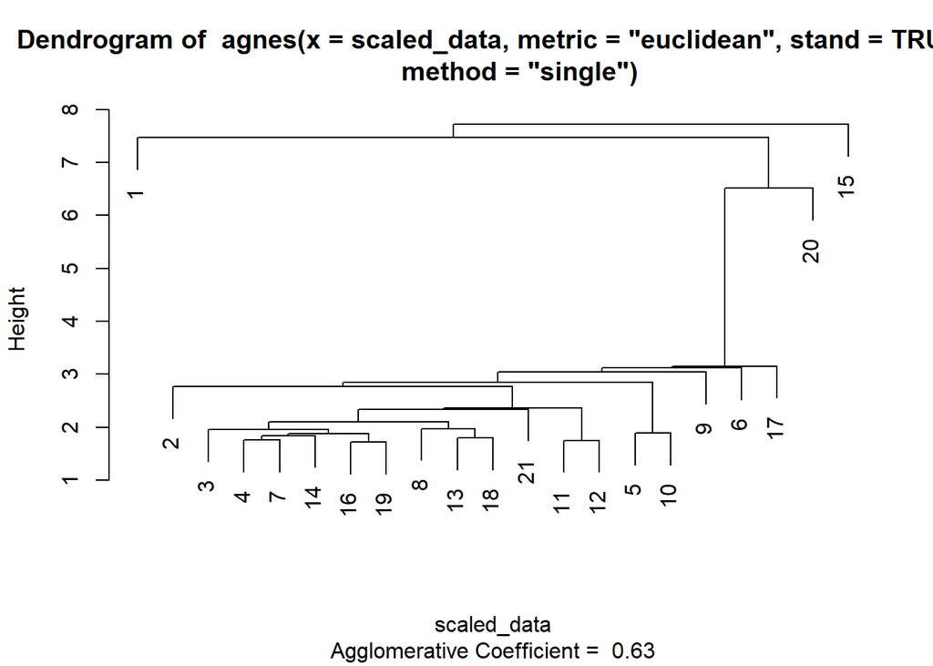

```r
plot(agn.sm, which.plots=2)
```

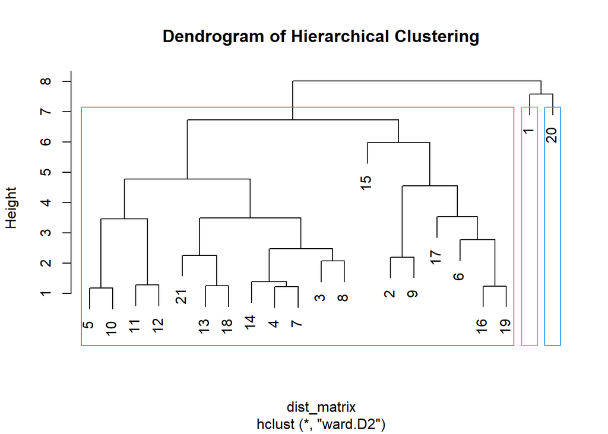

```r
# Cut the dendrogram to obtain clusters
num_clusters <- 3  # Choose the number of clusters
clusters <- cutree(hclust_result, k = num_clusters)

# Visualize the dendrogram
plot(hclust_result, main = "Dendrogram of Hierarchical Clustering")
rect.hclust(hclust_result, k = num_clusters, border = 2:5)
```

```r
# K-means, k=2, 3, 4, 5, 6
# Centers (k's) are numbers thus, 10 random sets are chosen

# Computing the percentage of variation accounted for. Two clusters
(kmeans2.sm <- kmeans(scaled_data,2,nstart = 10))
```

```
## K-means clustering with 2 clusters of sizes 11, 10
##
## Cluster means:
##   Instagram_Time Linkedin_Time Snapchat_Time Twitter_Time Whatsapp_Time
## 1      0.4959808     0.5993419     0.3150924   -0.4307272     0.6003270
## 2     -0.5455789    -0.6592760    -0.3466016    0.4737999    -0.6603597
##   Youtube_Time     OTT_Time Reddit_Time
## 1    0.5363885 -0.007354170  -0.3007875
## 2   -0.5900274  0.008089587   0.3308662
##
## Clustering vector:
##  [1] 2 1 1 1 2 1 1 1 1 2 2 2 2 2 2 1 1 2 1 1 2
##
## Within cluster sum of squares by cluster:
## [1] 59.05999 63.31822
##  (between_SS / total_SS =  23.5 %)
##
## Available components:
##
## [1] "cluster"      "centers"      "totss"        "withinss"     "tot.withinss"
## [6] "betweenss"    "size"         "iter"         "ifault"
```

```r
# Computing the percentage of variation accounted for. Two clusters
perc.var.2 <- round(100*(1 - kmeans2.sm$betweenss/kmeans2.sm$totss),1)
names(perc.var.2) <- "Perc. 2 clus"
perc.var.2
```

```
## Perc. 2 clus
##         76.5
```

```r
# Computing the percentage of variation accounted for. Three clusters
(kmeans3.sm <- kmeans(scaled_data,3,nstart = 10))
```

```
## K-means clustering with 3 clusters of sizes 1, 9, 11
##
## Cluster means:
##   Instagram_Time Linkedin_Time Snapchat_Time Twitter_Time Whatsapp_Time
## 1     -0.5359407     0.1518958    -0.1625326   3.42451853    -1.3320450
## 2      0.6046939     0.6396725     0.4640202  -0.42655312     0.7715887
## 3     -0.4460276    -0.5371771    -0.3648772   0.03767815    -0.5102049
##   Youtube_Time    OTT_Time Reddit_Time
## 1   -0.2720252  3.43822885   1.2404888
## 2    0.7160360  0.07666234  -0.2944448
## 3   -0.5611181 -0.37529000   0.1281377
##
## Clustering vector:
##  [1] 1 2 2 3 3 2 3 2 2 3 3 3 3 3 3 2 2 3 2 2 3
##
## Within cluster sum of squares by cluster:
## [1]  0.00000 53.15632 43.31722
##  (between_SS / total_SS =  39.7 %)
##
## Available components:
##
## [1] "cluster"      "centers"      "totss"        "withinss"     "tot.withinss"
## [6] "betweenss"    "size"         "iter"         "ifault"
```

```r
# Computing the percentage of variation accounted for. Two clusters
perc.var.3 <- round(100*(1 - kmeans3.sm$betweenss/kmeans3.sm$totss),1)
names(perc.var.3) <- "Perc. 3 clus"
perc.var.3
```

```
## Perc. 3 clus
##         60.3
```

```r
# Computing the percentage of variation accounted for. Four clusters
(kmeans4.sm <- kmeans(scaled_data,4,nstart = 10))
```

```
## K-means clustering with 4 clusters of sizes 11, 8, 1, 1
##
## Cluster means:
##   Instagram_Time Linkedin_Time Snapchat_Time Twitter_Time Whatsapp_Time
## 1      0.2231992     0.5919966    0.02001516   -0.4307272     0.3993301
## 2     -0.5895964    -0.8494444   -0.42127218    0.2203738    -0.6641943
## 3     -0.5359407     0.1518958   -0.16253261    3.4245185    -1.3320450
## 4      2.7975209     0.1316965    3.31254334   -0.4495103     2.2529688
##   Youtube_Time   OTT_Time Reddit_Time
## 1    0.4299953 -0.2154882  0.09880266
## 2   -0.7150938 -0.4039419 -0.24974856
## 3   -0.2720252  3.4382289  1.24048879
## 4    1.2628271  2.1636764 -0.32932963
##
## Clustering vector:
##  [1] 3 1 1 1 2 1 1 1 1 2 2 2 2 2 1 1 1 2 1 4 2
##
## Within cluster sum of squares by cluster:
## [1] 52.45188 19.15592  0.00000  0.00000
##  (between_SS / total_SS =  55.2 %)
##
## Available components:
##
## [1] "cluster"      "centers"      "totss"        "withinss"     "tot.withinss"
## [6] "betweenss"    "size"         "iter"         "ifault"
```

```r
perc.var.4 <- round(100*(1 - kmeans4.sm$betweenss/kmeans4.sm$totss),1)
names(perc.var.4) <- "Perc. 4 clus"
perc.var.4
```

```
## Perc. 4 clus
##         44.8
```

```r
# Computing the percentage of variation accounted for. Five clusters
(kmeans5.sm <- kmeans(scaled_data,5,nstart = 10))
```

```
## K-means clustering with 5 clusters of sizes 10, 1, 1, 8, 1
##
## Cluster means:
##   Instagram_Time Linkedin_Time Snapchat_Time Twitter_Time Whatsapp_Time
## 1      0.2658268    0.64610639    0.01534727   -0.4288488    0.43506286
## 2     -0.2030769    0.05089913    0.06669404   -0.4495103    0.04200212
## 3      2.7975209    0.13169650    3.31254334   -0.4495103    2.25296879
## 4     -0.5895964   -0.84944443   -0.42127218    0.2203738   -0.66419432
## 5     -0.5359407    0.15189584   -0.16253261    3.4245185   -1.33204496
##   Youtube_Time   OTT_Time Reddit_Time
## 1   0.46374465 -0.2244572  -0.2979333
## 2   0.09250226 -0.1257974   4.0661619
## 3   1.26282710  2.1636764  -0.3293296
## 4  -0.71509383 -0.4039419  -0.2497486
## 5  -0.27202515  3.4382289   1.2404888
##
## Clustering vector:
##  [1] 5 1 1 1 4 1 1 1 1 4 4 4 4 4 2 1 1 4 1 3 4
##
## Within cluster sum of squares by cluster:
## [1] 34.33862  0.00000  0.00000 19.15592  0.00000
##  (between_SS / total_SS =  66.6 %)
##
## Available components:
##
## [1] "cluster"      "centers"      "totss"        "withinss"     "tot.withinss"
## [6] "betweenss"    "size"         "iter"         "ifault"
```

```r
perc.var.5 <- round(100*(1 - kmeans5.sm$betweenss/kmeans5.sm$totss),1)
names(perc.var.5) <- "Perc. 5 clus"
perc.var.5
```

```
## Perc. 5 clus
##         33.4
```

```r
# Computing the percentage of variation accounted for. Six clusters
(kmeans6.sm <- kmeans(scaled_data,6,nstart = 10))
```

```
## K-means clustering with 6 clusters of sizes 1, 6, 5, 7, 1, 1
##
## Cluster means:
##   Instagram_Time Linkedin_Time Snapchat_Time Twitter_Time Whatsapp_Time
## 1     -0.5359407    0.15189584   -0.16253261    3.4245185   -1.33204496
## 2      0.2897865    0.08680907   -0.09834915   -0.4150745    0.55969865
## 3      0.2677564    1.05009322    0.21156528   -0.4495103    0.22937218
## 4     -0.7337149   -0.87225886   -0.52634804    0.3160716   -0.78113982
## 5     -0.2030769    0.05089913    0.06669404   -0.4495103    0.04200212
## 6      2.7975209    0.13169650    3.31254334   -0.4495103    2.25296879
##   Youtube_Time   OTT_Time Reddit_Time
## 1  -0.27202515  3.4382289   1.2404888
## 2  -0.44629484 -0.1423194  -0.3293296
## 3   1.21294440 -0.2721349  -0.2665369
## 4  -0.63860817 -0.4659310  -0.2383798
## 5   0.09250226 -0.1257974   4.0661619
## 6   1.26282710  2.1636764  -0.3293296
##
## Clustering vector:
##  [1] 1 3 2 2 4 3 2 2 3 4 4 4 4 4 5 3 2 2 3 6 4
##
## Within cluster sum of squares by cluster:
## [1]  0.00000 12.85219 15.35465 15.51660  0.00000  0.00000
##  (between_SS / total_SS =  72.7 %)
##
## Available components:
##
## [1] "cluster"      "centers"      "totss"        "withinss"     "tot.withinss"
## [6] "betweenss"    "size"         "iter"         "ifault"
```

```r
perc.var.6 <- round(100*(1 - kmeans6.sm$betweenss/kmeans6.sm$totss),1)
names(perc.var.6) <- "Perc. 6 clus"
perc.var.6
```

```
## Perc. 6 clus
##         27.3
```

```r
Variance_List <- c(perc.var.2,perc.var.3,perc.var.4,perc.var.5,perc.var.6)
Variance_List
```

```
## Perc. 2 clus Perc. 3 clus Perc. 4 clus Perc. 5 clus Perc. 6 clus
##         76.5         60.3         44.8         33.4         27.3
```

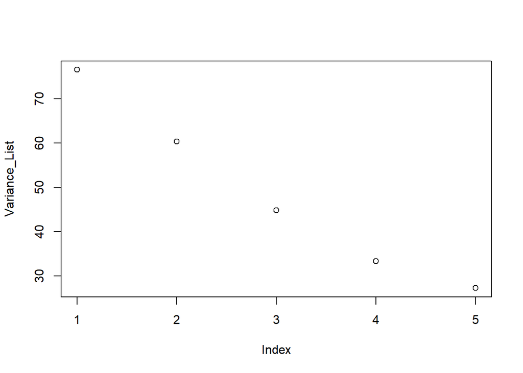

```r
plot(Variance_List)
```

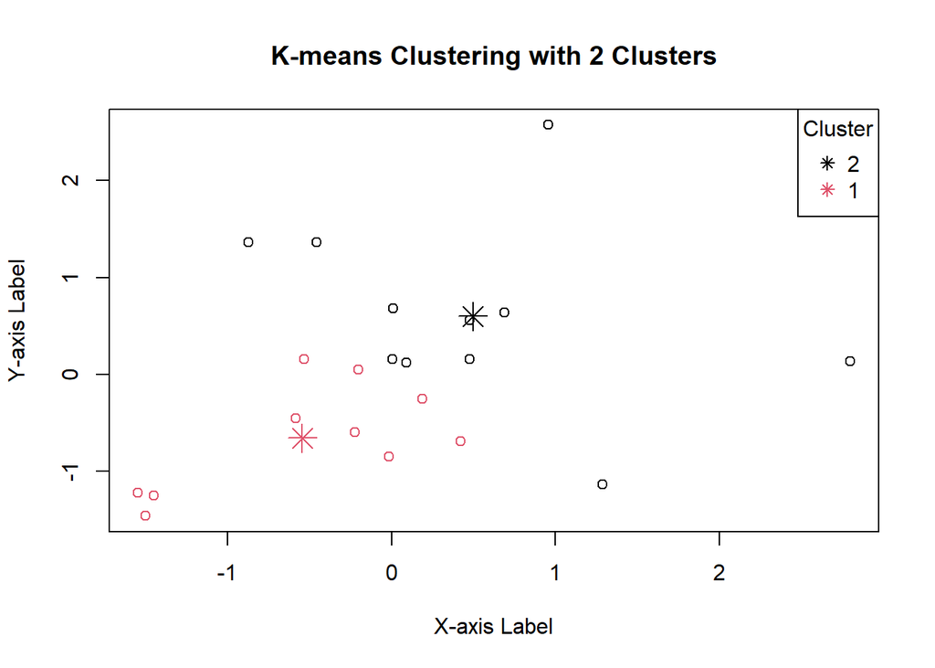

```r
# Plot clusters
plot(scaled_data, col = kmeans2.sm$cluster,
      main = "K-means Clustering with 2 Clusters",
      xlab = "X-axis Label", ylab = "Y-axis Label")

# Add cluster centers to the plot
points(kmeans2.sm$centers, col = 1:2, pch = 8, cex = 2)

# Add legend
legend("topright", legend = unique(kmeans2.sm$cluster),
        col = 1:2, pch = 8, title = "Cluster")
```

The agglomerative coefficient of 0.631 suggests moderate clustering structure in the data.

Models: Multiple Linear Regression:

```r
sm_model_fit <- lm(Weekly_Feelings ~ ., data = combined_data)
#show the results
summary(sm_model_fit)
```

```
##
## Call:
## lm(formula = Weekly_Feelings ~ ., data = combined_data)
##
## Residuals:
##     Min      1Q  Median      3Q     Max
## -1.0318 -0.2972 -0.1194  0.2302  1.1350
##
## Coefficients:
##                Estimate Std. Error t value Pr(>|t|)
## (Intercept)     2.86492    0.53171   5.388 0.000163 ***
## Instagram_Time  0.04279    0.08835   0.484 0.636857
## Linkedin_Time   0.16550    0.08178   2.024 0.065845 .
## Snapchat_Time  -0.25131    0.18401  -1.366 0.197077
## Twitter_Time   -0.06180    0.26347  -0.235 0.818516
## Whatsapp_Time   0.02669    0.07197   0.371 0.717265
## Youtube_Time   -0.02895    0.11879  -0.244 0.811609
## OTT_Time        0.01890    0.09721   0.194 0.849082
## Reddit_Time    -0.05963    0.11478  -0.519 0.612893
## ---
## Signif. codes:  0 '***' 0.001 '**' 0.01 '*' 0.05 '.' 0.1 ' ' 1
##
## Residual standard error: 0.766 on 12 degrees of freedom
## Multiple R-squared:  0.3682, Adjusted R-squared:  -0.05306
## F-statistic: 0.874 on 8 and 12 DF,  p-value: 0.5631
```

```r
#Summary has three sections. Section1: How well does the model fit the data (before Coefficients). Section2: Is the hypothesis supported? (until sifnif codes). Section3: How well does data fit the model (again).
# Useful Helper Functions
coefficients(sm_model_fit)
```

```
##    (Intercept) Instagram_Time  Linkedin_Time  Snapchat_Time   Twitter_Time
##     2.86491639     0.04279150     0.16549941    -0.25130748    -0.06179600
##  Whatsapp_Time   Youtube_Time       OTT_Time    Reddit_Time
##     0.02668657    -0.02894514     0.01890180    -0.05962516
```

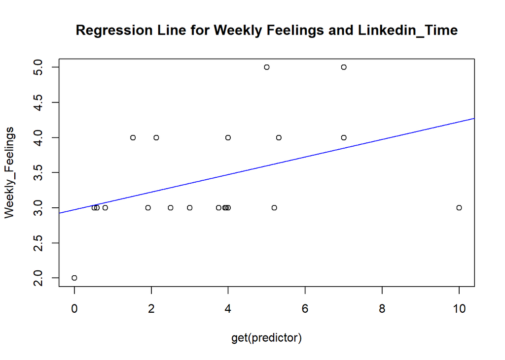

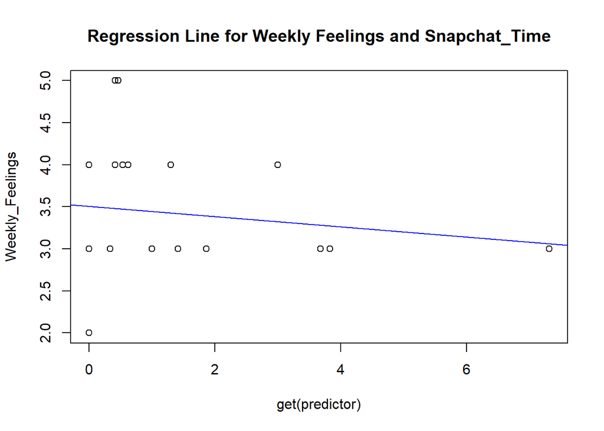

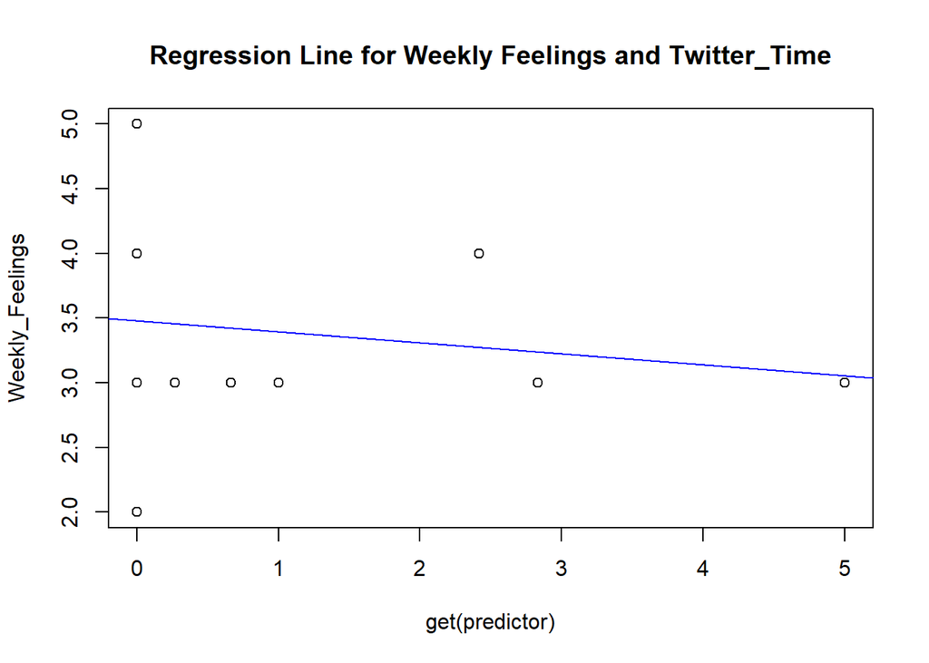

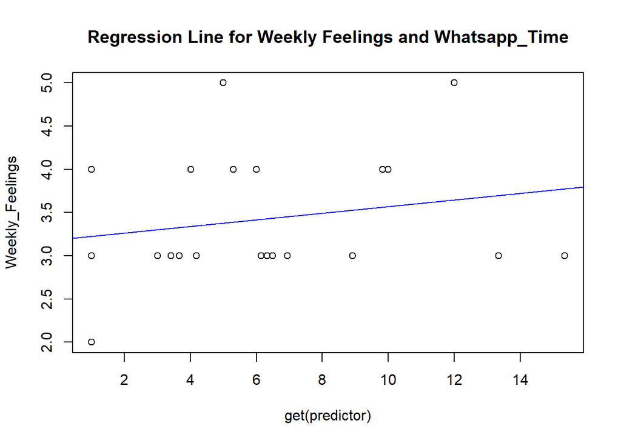

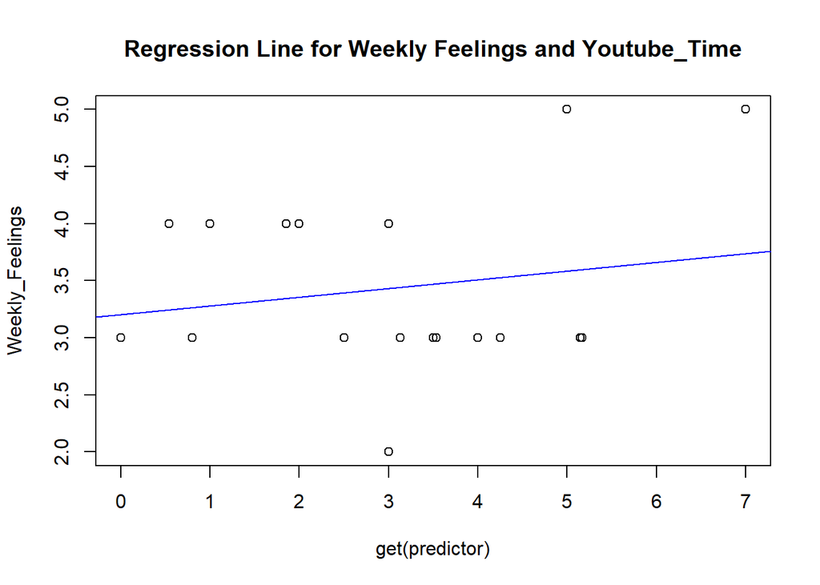

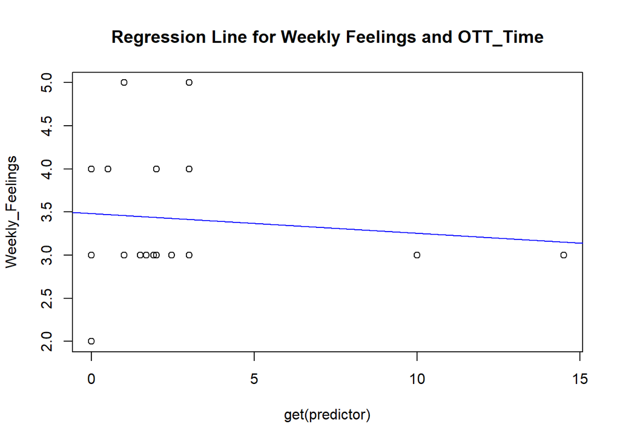

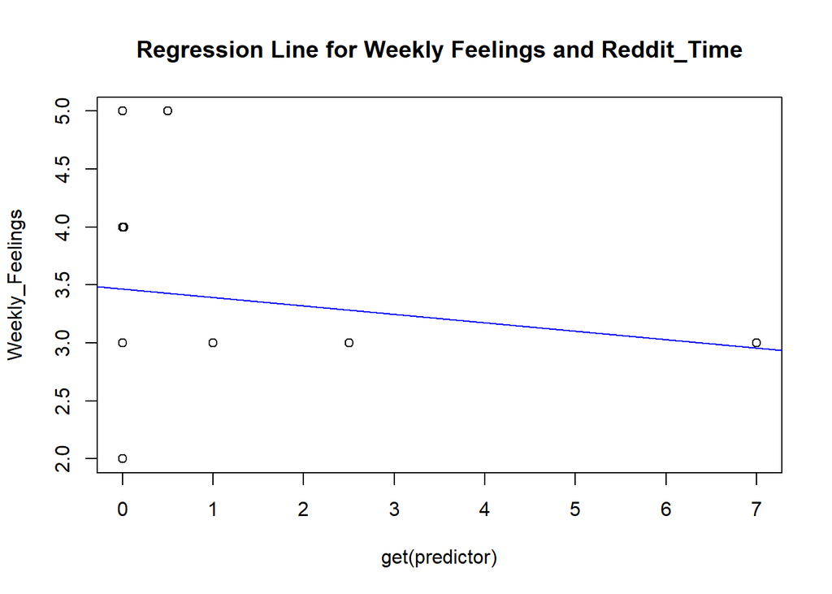

```r
predictor_vars <- c("Linkedin_Time", "Snapchat_Time", "Twitter_Time", "Whatsapp_Time", "Youtube_Time", "OTT_Time", "Reddit_Time")
for (predictor in predictor_vars) {
  plot(Weekly_Feelings ~ get(predictor), data = combined_data,
       main = paste("Regression Line for Weekly Feelings and", predictor))
  abline(lm(Weekly_Feelings ~ get(predictor), data = combined_data), col = "blue")
}
```